# Le modèle d'approximation quantique

L'utilisation de pytorch pour le dévellopement de ce modèle et plus que justifier

# Le Modèle mono-qubit amélioré

Dans une section précedante nous avons remarquer la limite d'expressivité du modèle quantique mono-qubit.

Et si cette limite ne venais pas du fait que l'on utilise qu'un simple qubit mais plutot de la simplicité du circuit ?

C'est la thèse que soutient le document de référence.

Nous allons définir le premier modèle mais avant tout nous allons redéfinir les porte essentielle pour le circuit :

```python
from source.quantum_circuit import *

quantum_circuit.clear_gates()

# On définit G(X)

quantum_circuit.add_door("G", "RX(v)")

# On définit S(X)

quantum_circuit.add_door("S", "G(v)")

# On définit W(theta)

quantum_circuit.add_door("W", "RZ(v)-RY(v)-RZ(v)")

quantum_circuit.add_door("L", "W(v,v,v)-S(v)")

quantum_circuit.display_gates()
```

```
| Name     | Code/Function                                 |
|----------|-----------------------------------------------|
| I        | quantum_door.I                                |
| *        | quantum_door.I                                |
| X        | quantum_door.Pauli_X                          |
| Y        | quantum_door.Pauli_Y                          |
| Z        | quantum_door.Pauli_Z                          |
| H        | quantum_door.Hadamard                         |
| S        | composite_gate                                |
| T        | quantum_door.T                                |
| RX       | quantum_door.RX                               |
| RY       | quantum_door.RY                               |
| RZ       | quantum_door.RZ                               |
| CNOT     | quantum_entangling_gate.CNOT                  |
| CX       | quantum_entangling_gate.CNOT                  |
| CCNOT    | quantum_entangling_gate.CCNOT                 |
| CCX      | quantum_entangling_gate.CCNOT                 |
| CZ       | quantum_entangling_gate.CZ                    |
| SWAP     | quantum_entangling_gate.SWAP                  |
| ISWAP    | quantum_entangling_gate.ISWAP                 |
| CSWAP    | quantum_entangling_gate.CSWAP                 |
| GHZ      | quantum_entangling_gate.GHZ                   |
| G        | composite_gate                                |
| W        | composite_gate                                |
| L        | composite_gate                                |
```

Maintenant que les portes sont ajoutées, nous allons redéfinir notre modèle quantique mono-qubit, mais adapté à notre simulateur quantique.

On reprend notre Adam coder en version numpy :

```python
class AdamOptimizer:
    def __init__(self, learning_rate=0.01, beta1=0.9, beta2=0.999, epsilon=1e-8, delta=1e-5):
        self.learning_rate = learning_rate
        self.beta1 = beta1
        self.beta2 = beta2
        self.epsilon = epsilon
        self.delta = delta
        self.t = 0
        self.m = None
        self.v = None

    def compute_gradient(self, f, w):
        grad = np.zeros_like(w)
        for idx in np.ndindex(w.shape):
            w_plus = np.copy(w)
            w_minus = np.copy(w)
            w_plus[idx] += self.delta
            w_minus[idx] -= self.delta
            grad[idx] = (f(w_plus) - f(w_minus)) / (2 * self.delta)
        return grad

    def step(self, f, w):
        if self.m is None:
            self.m = np.zeros_like(w)
        if self.v is None:
            self.v = np.zeros_like(w)
        self.t += 1
        grad = self.compute_gradient(f, w)
        self.m = self.beta1 * self.m + (1 - self.beta1) * grad
        self.v = self.beta2 * self.v + (1 - self.beta2) * (grad ** 2)
        m_hat = self.m / (1 - self.beta1 ** self.t)
        v_hat = self.v / (1 - self.beta2 ** self.t)
        w_new = w - self.learning_rate * m_hat / (np.sqrt(v_hat) + self.epsilon)
        return w_new
```

Nous allons reprendre notre modèle mono-qubit mais adapter pour interagir avec notre simulation :

NB : pour tous détails, consultez les commentaires dans cette section de code ; si une section n'est pas claire, c'est qu'elle a été abordée dans la section du premier modèle quantique.

```python
import matplotlib.pyplot as plt

class QuantumModel:

    def __init__(self, circuit, gamma):

        self.circuit = circuit

        # Comptage dynamique du nombre de couches représenté par la forme "v,v,v"
        self.num_layers = len(re.findall(r"v(?:\s*,\s*v){2}", circuit))

        self.gamma = gamma
        self.weights = 0.1 * np.random.randn(self.num_layers,3)
        quantum_circuit(circuit.replace('x', 'v')).draw()


    # interface d'utilisation du simulateur
    def _simulate_circuit(self, x, weights):

        # on récupère les positions pour envoyer les valeurs dynamiquement dans le circuit
        tokens = re.findall(r"v|x", self.circuit)

        # on convertit le circuit pour qu'il soit utilisable par le simulateur
        circuit_str = self.circuit.replace('x', 'v')

        # On initialise le simulateur
        simulator = quantum_circuit(circuit_str)

        # On convertit tous les poids sous forme de liste pour les aligner dans le circuit quantique
        flat_weights = weights.flatten()

        # liste des valeurs de remplacement avec l'index d'avancement
        replacement_values = []
        weight_index = 0

        # position par position, on positionne les valeurs selon les choix exposés dans le circuit
        for token in tokens:
            if token == 'x':
                replacement_values.append(float(self.gamma * x))
            else:
                replacement_values.append(float(flat_weights[weight_index]))
                weight_index += 1

        # On les introduit dans le circuit
        simulator.replace_values(replacement_values)

        # On récupère les qubits de mesures après leur passage dans le circuit
        qubits = simulator.apply_circuit()  # Renvoie la liste des états de chacun des qubits

        pauliZ = np.array([[1,  0],
                   [0, -1]], dtype=complex)

        def expval_z(psi):
            psi = psi / np.linalg.norm(psi)   # s’assure que psi est normalisé
            return np.vdot(psi, pauliZ @ psi).real
        mesure = np.sum([(expval_z(q)) for q in qubits])

        return mesure



    # fonction de forward dans le ciruit
    def forward(self, x):
        outputs = []
        # On place tous les x dans le circuit, les uns après les autres, pour l'entraînement
        for x_i in x:
            outputs.append(self._simulate_circuit(x_i, self.weights))
        return np.array(outputs)

    def square_loss(self, targets, predictions):
        loss = np.mean((targets - predictions)**2)
        return 0.5 * loss

    def compute_loss(self, x_batch, y_batch, weights=None):
        if weights is None:
            weights = self.weights

        preds = []

        # Application du circuit sur chaque élément de x_batch
        for x_i in x_batch:
            preds.append(self._simulate_circuit(x_i, weights))

        # Retourne la perte quadratique
        return self.square_loss(y_batch, preds)

    def load_weights(self, weights):
        self.weights = weights.copy()


    def train(self, target_function, linespace=(-6,6), number_points=100,
          steps=1000, learning_rate=0.3, batch_size=25, plot=True):

        x = np.linspace(linespace[0], linespace[1], number_points, dtype=np.float32)
        y = np.array([target_function(x_) for x_ in x], dtype=np.float32)
        optimizer = AdamOptimizer(learning_rate=learning_rate)
        cost_history = []

        for step in range(steps):
            indices = np.random.choice(len(x), batch_size, replace=False)
            x_batch = x[indices]
            y_batch = y[indices]

            def loss_closure(w):
                return self.compute_loss(x_batch, y_batch, weights=w)

            self.weights = optimizer.step(loss_closure, self.weights)
            loss_value = self.compute_loss(x_batch, y_batch)
            cost_history.append(loss_value)
            if((step+1) % 10 == 0):
                print(f"Step {step + 1}: Loss = {loss_value:.6f}")


        if plot:
            plt.figure(figsize=(12, 5))

            plt.subplot(1, 2, 1)
            plt.plot(range(len(cost_history)), cost_history, label="Loss", linewidth=2)
            plt.title("Évolution de la Loss (Adam)")
            plt.xlabel("Itération")
            plt.ylabel("Loss")
            plt.legend()

            plt.subplot(1, 2, 2)
            plt.plot(x, y, label="Fonction cible", linewidth=2)
            plt.plot(x, self.forward(x), '--', label="Prédiction", linewidth=2)
            plt.title("Approximation de la fonction")
            plt.xlabel("x")
            plt.ylabel("Valeur")
            plt.legend()

            plt.tight_layout()
            plt.show()

        return cost_history, self.weights
```

Nous définissons une fonction d'approximation pour simplifier la mise en place d'exemples, qui va initialiser les fonctions, les modèles et leur entraînement rapidement en regroupant tous les hyperparamètres.

- *function* : fonction à approximer
- *circuit* : circuit support dans le simulateur
- *linespace* : espace de la fonction à approximer
- *number_points* : nombre de points dans la fonction
- *gamma* : gamma
- *steps* : nombre d'étapes d'entraînement
- *learning_rate* : taux d'apprentissage du modèle

```python
def approximate(
        function,
        circuit,
        linespace,
        number_points,
        gamma,
        steps,
        learning_rate,
    ):

    quantum_model = QuantumModel(circuit, gamma)
    quantum_model.train(function, linespace=linespace, number_points=number_points,
                          steps=steps, learning_rate=learning_rate, batch_size=25, plot=True)
```

Nous définissons le circuit pour une fonction sinus de base comme dans le premier modèle :

```
--- Circuit ---
|0⟩—[L(0j,—0j,—0j,—0j)]—[W(0j,—0j,—0j)]—> M

Step 10: Loss = 0.066257
Step 20: Loss = 0.005692
Step 30: Loss = 0.008230
Step 40: Loss = 0.000472
Step 50: Loss = 0.001271
Step 60: Loss = 0.000409
Step 70: Loss = 0.000045
Step 80: Loss = 0.000004
Step 90: Loss = 0.000016
Step 100: Loss = 0.000010
```

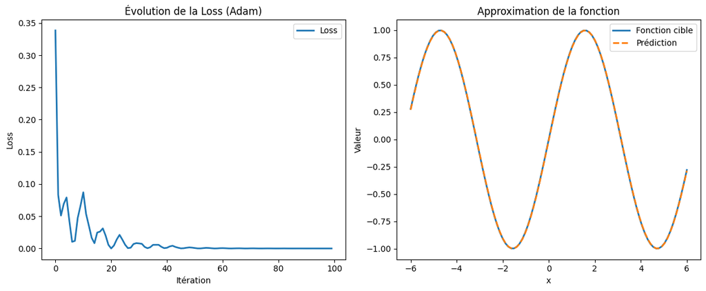

```python
def sin(x):
    return np.sin(x)

# Définition du circuit avec un layer pour approximer la fonction sinus
num_layer = 1
circuit = ("L(v,v,v,x)-" * num_layer) + "W(v,v,v)"

# Lancement de l'approximation

approximate(
        sin,
        circuit,
        linespace = (-6,6),
        number_points = 100,
        gamma = 1,
        steps = 100,
        learning_rate = 0.3,
    )
```

# Introduction d'une fonction plus compexe à approximer

Nous définissons une fonction inspirée du document en question pour réaliser son approximation :

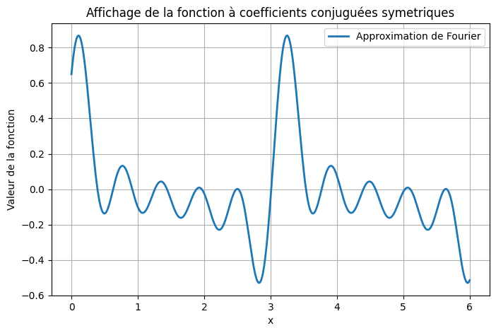

```python
import numpy as np
def coefficients_conjugue_symetrique(x):
    n_values = np.arange(-5, 6)
    c_n = np.array([
        2 * (0.05 + 0.05j) if n < 0 else (0 if n == 0 else 2 * (0.05 - 0.05j))
        for n in n_values
    ])
    fourier_sum = np.sum(c_n * np.exp(2j * n_values * x))
    f_value = np.real(fourier_sum)
    return f_value * 0.65

# Génération des valeurs de x
x_values = np.linspace(0,6,400)
y_values = np.array([coefficients_conjugue_symetrique(x) for x in x_values])

# Affichage avec Matplotlib
plt.figure(figsize=(8, 5))
plt.plot(x_values, y_values, label="Approximation de Fourier", linewidth=2)
plt.title("Affichage de la fonction à coefficients conjuguées symetriques")
plt.xlabel("x")
plt.ylabel("Valeur de la fonction")
plt.legend()
plt.grid()
plt.show()
```

On lance l'approximation avec le modèle précédent avec un $\theta$ à 10 causé par les 10 oscillations.

```
--- Circuit ---
|0⟩—[L(0j,—0j,—0j,—0j)]—[W(0j,—0j,—0j)]—> M

Step 10: Loss = 0.197139
Step 20: Loss = 0.196813
Step 30: Loss = 0.162784
Step 40: Loss = 0.147704
Step 50: Loss = 0.041963
Step 60: Loss = 0.032243
Step 70: Loss = 0.020899
Step 80: Loss = 0.053562
Step 90: Loss = 0.034246
Step 100: Loss = 0.034923
Step 110: Loss = 0.033683
Step 120: Loss = 0.038403
Step 130: Loss = 0.034334
Step 140: Loss = 0.020911
Step 150: Loss = 0.014681
Step 160: Loss = 0.020456
Step 170: Loss = 0.027672
Step 180: Loss = 0.044442
Step 190: Loss = 0.044118
Step 200: Loss = 0.049012
```

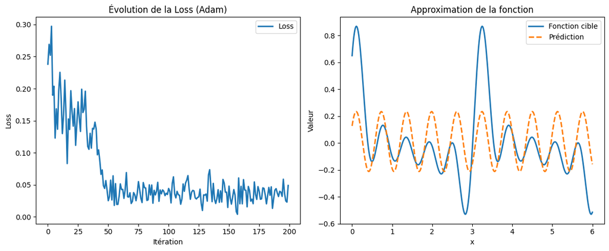

```python
approximate(
        coefficients_conjugue_symetrique,
        circuit,
        linespace = (0,6),
        number_points = 400,
        gamma = 10,
        steps = 200,
        learning_rate = 0.05,
    )
```

L'approximation n'est pas possible, comme vu dans le document de référence.

On augmente le nombre de layer à 3 avec un gamme reduit à 4

```
--- Circuit ---
|0⟩—[L(0j,—0j,—0j,—0j)]—[L(0j,—0j,—0j,—0j)]—[L(0j,—0j,—0j,—0j)]—[W(0j,—0j,—0j)]—> M

Step 10: Loss = 0.139005
Step 20: Loss = 0.044723
Step 30: Loss = 0.038059
Step 40: Loss = 0.026363
Step 50: Loss = 0.048655
Step 60: Loss = 0.033963
Step 70: Loss = 0.029931
Step 80: Loss = 0.030135
Step 90: Loss = 0.030490
Step 100: Loss = 0.021197
Step 110: Loss = 0.026872
Step 120: Loss = 0.019856
Step 130: Loss = 0.024205
Step 140: Loss = 0.020365
Step 150: Loss = 0.013713
Step 160: Loss = 0.031079
Step 170: Loss = 0.031211
Step 180: Loss = 0.020459
Step 190: Loss = 0.026033
Step 200: Loss = 0.038684
```

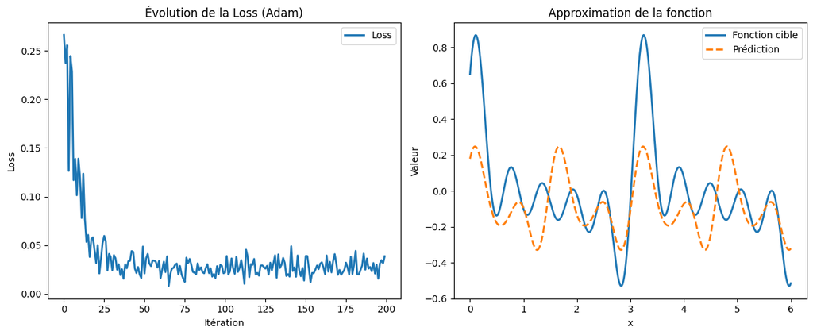

```python
# Définition du circuit avec un layer pour approximer la à coefficients conjuguées
num_layer = 3
circuit = ("L(v,v,v,x)-" * num_layer) + "W(v,v,v)"

# Lancement de l'approximation

approximate(
        coefficients_conjugue_symetrique,
        circuit,
        linespace = (0,6),
        number_points = 400,
        gamma = 4,
        steps = 200,
        learning_rate = 0.05,
    )
```

La encore la modèle n'est pas assez performant pour approximer la fonction on passse avec un layer fixé à 5 et un gamma fixé à 2

```
--- Circuit ---
|0⟩—[L(0j,—0j,—0j,—0j)]—[L(0j,—0j,—0j,—0j)]—[L(0j,—0j,—0j,—0j)]—[L(0j,—0j,—0j,—0j)]—[L(0j,—0j,—0j,—0j)]—[W(0j,—0j,—0j)]—> M

Step 10: Loss = 0.032747
Step 20: Loss = 0.035440
Step 30: Loss = 0.011273
Step 40: Loss = 0.004322
Step 50: Loss = 0.002460
Step 60: Loss = 0.001147
Step 70: Loss = 0.000487
Step 80: Loss = 0.000118
Step 90: Loss = 0.000046
Step 100: Loss = 0.000006
Step 110: Loss = 0.000014
Step 120: Loss = 0.000003
Step 130: Loss = 0.000001
Step 140: Loss = 0.000001
Step 150: Loss = 0.000001
Step 160: Loss = 0.000000
Step 170: Loss = 0.000000
Step 180: Loss = 0.000000
Step 190: Loss = 0.000000
Step 200: Loss = 0.000000
```

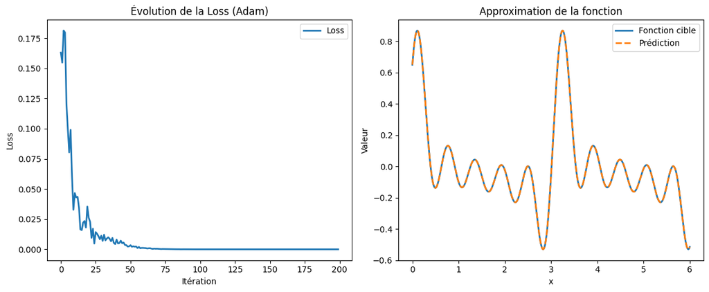

```python
# Définition du circuit avec un layer pour approximer la fonction à coefficients conjuguées
num_layer = 5
circuit = ("L(v,v,v,x)-" * num_layer) + "W(v,v,v)"

# Lancement de l'approximation

approximate(
        coefficients_conjugue_symetrique,
        circuit,
        linespace = (0,6),
        number_points = 400,
        gamma = 2,
        steps = 200,
        learning_rate = 0.05,
    )
```

La complexité d'un circuit peut permettre d'offrir la possibilité d'approximer des fonctions plus complexes, mais nous pouvons l'améliorer et le rendre plus rapide en séparant les calculs entre plusieurs couches de qubits.

# Les circuits multi-qubits

Maintenant, nous allons passer à l'approximation de modèle avec des circuits avec plusieurs qubits.

```
--- Circuit ---
|0⟩—[L(0j,—0j,—0j,—0j)]——⊕——[L(0j,—0j,—0j,—0j)]—————————> M
|1⟩—[L(0j,—0j,—0j,—0j)]——⬤——[L(0j,—0j,—0j,—0j)]——⊕——> M
|2⟩—[L(0j,—0j,—0j,—0j)]—————————[L(0j,—0j,—0j,—0j)]——⬤——> M

Step 10: Loss = 0.019981
Step 20: Loss = 0.004049
Step 30: Loss = 0.001505
Step 40: Loss = 0.000124
Step 50: Loss = 0.000110
Step 60: Loss = 0.000045
Step 70: Loss = 0.000030
Step 80: Loss = 0.000010
Step 90: Loss = 0.000004
Step 100: Loss = 0.000001
```

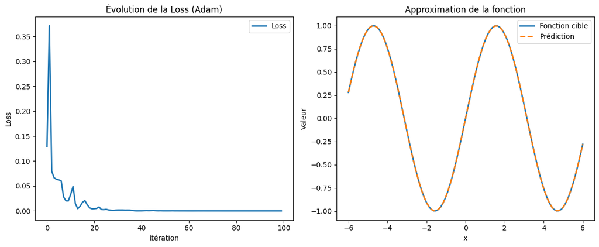

```python
circuit =  """
L(v,v,v,x)-CX#1-L(v,v,v,x)-I
L(v,v,v,x)-CX#2-L(v,v,v,x)-CX#1
L(v,v,v,x)-I-L(v,v,v,x)-CX#2
"""


# Lancement de l'approximation

approximate(
        sin,
        circuit,
        linespace = (-6,6),
        number_points = 100,
        gamma = 1,
        steps = 100,
        learning_rate = 0.8,
    )
```

On voit bien que l'approximation est correcte.

On essaie à présent d'approximer la fonction à coefficients conjugées symetriques

```
--- Circuit ---
|0⟩—[L(0j,—0j,—0j,—0j)]——⊕——[L(0j,—0j,—0j,—0j)]—————————> M
|1⟩—[L(0j,—0j,—0j,—0j)]——⬤——[L(0j,—0j,—0j,—0j)]——⊕——> M
|2⟩—[L(0j,—0j,—0j,—0j)]—————————[L(0j,—0j,—0j,—0j)]——⬤——> M

Step 10: Loss = 0.040061
Step 20: Loss = 0.033915
Step 30: Loss = 0.043713
Step 40: Loss = 0.024378
Step 50: Loss = 0.035843
Step 60: Loss = 0.028110
Step 70: Loss = 0.011891
Step 80: Loss = 0.023405
Step 90: Loss = 0.033903
Step 100: Loss = 0.019982
Step 110: Loss = 0.041390
Step 120: Loss = 0.029274
Step 130: Loss = 0.030662
Step 140: Loss = 0.024480
Step 150: Loss = 0.025422
Step 160: Loss = 0.020977
Step 170: Loss = 0.029703
Step 180: Loss = 0.027254
Step 190: Loss = 0.018109
Step 200: Loss = 0.016111
```

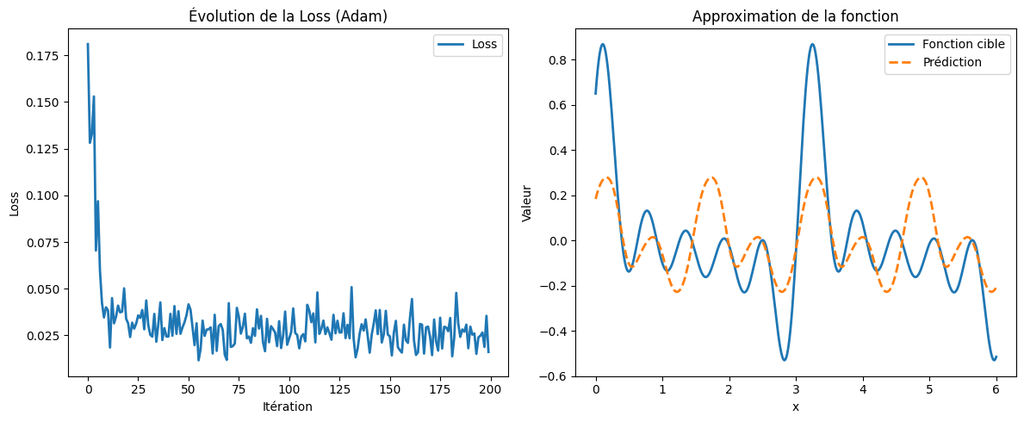

```python
approximate(
        coefficients_conjugue_symetrique,
        circuit,
        linespace = (0,6),
        number_points = 400,
        gamma = 4,
        steps = 200,
        learning_rate = 0.05,
    )
```

```
--- Circuit ---
|0⟩—[L(0j,—0j,—0j,—0j)]——⊕——[L(0j,—0j,—0j,—0j)]—————————[L(0j,—0j,—0j,—0j)]—————————[L(0j,—0j,—0j,—0j)]—————————[L(0j,—0j,—0j,—0j)]—> M
|1⟩—[L(0j,—0j,—0j,—0j)]——⬤——[L(0j,—0j,—0j,—0j)]—————————[L(0j,—0j,—0j,—0j)]——⊕——[L(0j,—0j,—0j,—0j)]—————————[L(0j,—0j,—0j,—0j)]—> M
|2⟩—[L(0j,—0j,—0j,—0j)]—————————[L(0j,—0j,—0j,—0j)]——⊕——[L(0j,—0j,—0j,—0j)]——⬤——[L(0j,—0j,—0j,—0j)]—————————[L(0j,—0j,—0j,—0j)]—> M
|3⟩—[L(0j,—0j,—0j,—0j)]—————————[L(0j,—0j,—0j,—0j)]——⬤——[L(0j,—0j,—0j,—0j)]—————————[L(0j,—0j,—0j,—0j)]——⊕——[L(0j,—0j,—0j,—0j)]—> M
|4⟩—[L(0j,—0j,—0j,—0j)]—————————[L(0j,—0j,—0j,—0j)]—————————[L(0j,—0j,—0j,—0j)]—————————[L(0j,—0j,—0j,—0j)]——⬤——[L(0j,—0j,—0j,—0j)]—> M

Step 10: Loss = 0.016972
Step 20: Loss = 0.006287
Step 30: Loss = 0.001992
Step 40: Loss = 0.000892
Step 50: Loss = 0.000354
Step 60: Loss = 0.000878
Step 70: Loss = 0.000283
Step 80: Loss = 0.000390
Step 90: Loss = 0.000191
Step 100: Loss = 0.000065
Step 110: Loss = 0.000093
Step 120: Loss = 0.000052
```

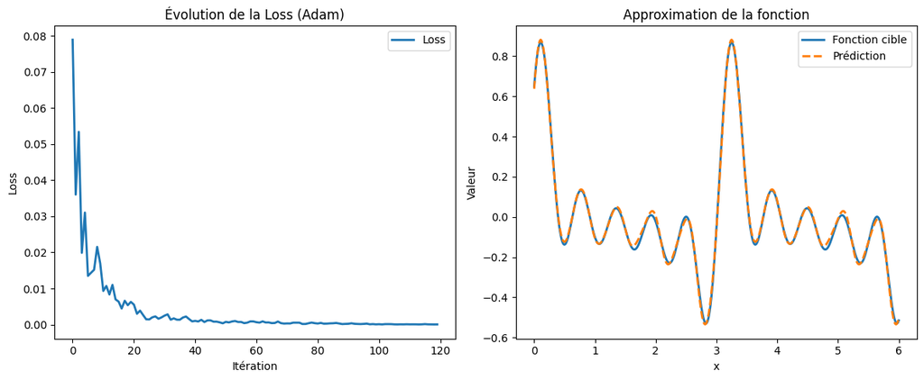

```python
circuit = """
L(v,v,v,x)-CX#1-L(v,v,v,x)-I-L(v,v,v,x)-I-L(v,v,v,x)-I-L(v,v,v,x)
L(v,v,v,x)-CX#2-L(v,v,v,x)-I-L(v,v,v,x)-CX#1-L(v,v,v,x)-I-L(v,v,v,x)
L(v,v,v,x)-I    -L(v,v,v,x)-CX#1-L(v,v,v,x)-CX#2-L(v,v,v,x)-I-L(v,v,v,x)
L(v,v,v,x)-I    -L(v,v,v,x)-CX#2-L(v,v,v,x)-I    -L(v,v,v,x)-CX#1-L(v,v,v,x)
L(v,v,v,x)-I    -L(v,v,v,x)-I    -L(v,v,v,x)-I    -L(v,v,v,x)-CX#2-L(v,v,v,x)
"""

approximate(
    coefficients_conjugue_symetrique,
    circuit,
    linespace = (0,6),
    number_points = 400,
    gamma = 2,
    steps = 120,
    learning_rate = 0.05
)
```